# Optimal Treatment Analysis

## Outcome Variable

**Outcome Variable:** whz

## Predictor Variables

**Intervention Variable:** predexfd6

**Adjustment Set:**

- arm
- sex
- brthmon
- W_mage
- meducyrs
- feducyrs
- hhwealth_quart
- hfoodsec
- W_mhtcm
- W_mwtkg
- W_mbmi
- vagbrth
- W_gagebrth
- W_birthwt
- W_birthlen
- W_nrooms
- W_nchldlt5
- month
- W_parity
- impfloor
- impsan
- safeh20
- delta_W_mage
- delta_meducyrs
- delta_feducyrs
- delta_hhwealth_quart
- delta_hfoodsec
- delta_W_mhtcm
- delta_W_mwtkg
- delta_W_mbmi
- delta_vagbrth
- delta_W_gagebrth
- delta_W_birthwt
- delta_W_birthlen
- delta_W_nrooms
- delta_W_nchldlt5
- delta_month
- delta_W_parity
- delta_impfloor
- delta_impsan
- delta_safeh20

## Stratifying Variables

The analysis was stratified on these variable(s):

- agecat
- studyid
- country

## Data Summary

| agecat | studyid | country | predexfd6 | n_cell | n |
| --- | --- | --- | --- | --- | --- |
| Birth | ki0047075b-MAL-ED | BANGLADESH | 1 | 68 | 194 |
| Birth | ki0047075b-MAL-ED | BANGLADESH | 0 | 126 | 194 |
| Birth | ki0047075b-MAL-ED | BRAZIL | 1 | 5 | 57 |
| Birth | ki0047075b-MAL-ED | BRAZIL | 0 | 52 | 57 |
| Birth | ki0047075b-MAL-ED | INDIA | 1 | 4 | 37 |
| Birth | ki0047075b-MAL-ED | INDIA | 0 | 33 | 37 |
| Birth | ki0047075b-MAL-ED | NEPAL | 1 | 3 | 23 |
| Birth | ki0047075b-MAL-ED | NEPAL | 0 | 20 | 23 |
| Birth | ki0047075b-MAL-ED | PERU | 1 | 72 | 208 |
| Birth | ki0047075b-MAL-ED | PERU | 0 | 136 | 208 |
| Birth | ki0047075b-MAL-ED | SOUTH AFRICA | 1 | 1 | 90 |
| Birth | ki0047075b-MAL-ED | SOUTH AFRICA | 0 | 89 | 90 |
| Birth | ki0047075b-MAL-ED | TANZANIA, UNITED REPUBLIC OF | 1 | 0 | 105 |
| Birth | ki0047075b-MAL-ED | TANZANIA, UNITED REPUBLIC OF | 0 | 105 | 105 |
| Birth | ki1000108-CMC-V-BCS-2002 | INDIA | 1 | 7 | 7 |
| Birth | ki1000108-CMC-V-BCS-2002 | INDIA | 0 | 0 | 7 |
| Birth | ki1000108-IRC | INDIA | 1 | 0 | 12 |
| Birth | ki1000108-IRC | INDIA | 0 | 12 | 12 |
| Birth | ki1000109-EE | PAKISTAN | 1 | 24 | 28 |
| Birth | ki1000109-EE | PAKISTAN | 0 | 4 | 28 |
| Birth | ki1000304b-SAS-CompFeed | INDIA | 1 | 310 | 325 |
| Birth | ki1000304b-SAS-CompFeed | INDIA | 0 | 15 | 325 |
| Birth | ki1017093b-PROVIDE | BANGLADESH | 1 | 155 | 532 |
| Birth | ki1017093b-PROVIDE | BANGLADESH | 0 | 377 | 532 |
| Birth | ki1101329-Keneba | GAMBIA | 1 | 450 | 1327 |
| Birth | ki1101329-Keneba | GAMBIA | 0 | 877 | 1327 |
| Birth | ki1113344-GMS-Nepal | NEPAL | 1 | 390 | 522 |
| Birth | ki1113344-GMS-Nepal | NEPAL | 0 | 132 | 522 |
| Birth | kiGH5241-JiVitA-3 | BANGLADESH | 1 | 8392 | 10744 |
| Birth | kiGH5241-JiVitA-3 | BANGLADESH | 0 | 2352 | 10744 |

[output cut: 70 more lines]

The following strata were considered:

- agecat: 24 months, studyid: ki0047075b-MAL-ED, country: BANGLADESH
- agecat: 24 months, studyid: ki0047075b-MAL-ED, country: BRAZIL
- agecat: 24 months, studyid: ki0047075b-MAL-ED, country: INDIA
- agecat: 24 months, studyid: ki0047075b-MAL-ED, country: NEPAL
- agecat: 24 months, studyid: ki0047075b-MAL-ED, country: PERU
- agecat: 24 months, studyid: ki0047075b-MAL-ED, country: SOUTH AFRICA
- agecat: 24 months, studyid: ki0047075b-MAL-ED, country: TANZANIA, UNITED REPUBLIC OF
- agecat: 24 months, studyid: ki1000108-CMC-V-BCS-2002, country: INDIA
- agecat: 24 months, studyid: ki1000108-IRC, country: INDIA
- agecat: 24 months, studyid: ki1000109-EE, country: PAKISTAN
- agecat: 24 months, studyid: ki1017093b-PROVIDE, country: BANGLADESH
- agecat: 24 months, studyid: ki1101329-Keneba, country: GAMBIA
- agecat: 24 months, studyid: ki1113344-GMS-Nepal, country: NEPAL
- agecat: 24 months, studyid: ki1148112-LCNI-5, country: MALAWI
- agecat: 24 months, studyid: kiGH5241-JiVitA-3, country: BANGLADESH
- agecat: 24 months, studyid: kiGH5241-JiVitA-4, country: BANGLADESH
- agecat: 6 months, studyid: ki0047075b-MAL-ED, country: BANGLADESH
- agecat: 6 months, studyid: ki0047075b-MAL-ED, country: BRAZIL
- agecat: 6 months, studyid: ki0047075b-MAL-ED, country: INDIA
- agecat: 6 months, studyid: ki0047075b-MAL-ED, country: NEPAL
- agecat: 6 months, studyid: ki0047075b-MAL-ED, country: PERU
- agecat: 6 months, studyid: ki0047075b-MAL-ED, country: SOUTH AFRICA
- agecat: 6 months, studyid: ki0047075b-MAL-ED, country: TANZANIA, UNITED REPUBLIC OF
- agecat: 6 months, studyid: ki1000108-CMC-V-BCS-2002, country: INDIA
- agecat: 6 months, studyid: ki1000108-IRC, country: INDIA
- agecat: 6 months, studyid: ki1000109-EE, country: PAKISTAN
- agecat: 6 months, studyid: ki1000304b-SAS-CompFeed, country: INDIA
- agecat: 6 months, studyid: ki1000304b-SAS-FoodSuppl, country: INDIA
- agecat: 6 months, studyid: ki1017093b-PROVIDE, country: BANGLADESH
- agecat: 6 months, studyid: ki1101329-Keneba, country: GAMBIA
- agecat: 6 months, studyid: ki1113344-GMS-Nepal, country: NEPAL
- agecat: 6 months, studyid: ki1148112-LCNI-5, country: MALAWI
- agecat: 6 months, studyid: kiGH5241-JiVitA-3, country: BANGLADESH
- agecat: 6 months, studyid: kiGH5241-JiVitA-4, country: BANGLADESH
- agecat: Birth, studyid: ki0047075b-MAL-ED, country: BANGLADESH
- agecat: Birth, studyid: ki0047075b-MAL-ED, country: BRAZIL
- agecat: Birth, studyid: ki0047075b-MAL-ED, country: INDIA
- agecat: Birth, studyid: ki0047075b-MAL-ED, country: NEPAL
- agecat: Birth, studyid: ki0047075b-MAL-ED, country: PERU
- agecat: Birth, studyid: ki0047075b-MAL-ED, country: SOUTH AFRICA
- agecat: Birth, studyid: ki0047075b-MAL-ED, country: TANZANIA, UNITED REPUBLIC OF
- agecat: Birth, studyid: ki1000108-CMC-V-BCS-2002, country: INDIA
- agecat: Birth, studyid: ki1000108-IRC, country: INDIA
- agecat: Birth, studyid: ki1000109-EE, country: PAKISTAN
- agecat: Birth, studyid: ki1000304b-SAS-CompFeed, country: INDIA
- agecat: Birth, studyid: ki1017093b-PROVIDE, country: BANGLADESH
- agecat: Birth, studyid: ki1101329-Keneba, country: GAMBIA
- agecat: Birth, studyid: ki1113344-GMS-Nepal, country: NEPAL
- agecat: Birth, studyid: kiGH5241-JiVitA-3, country: BANGLADESH
- agecat: Birth, studyid: kiGH5241-JiVitA-4, country: BANGLADESH

### Dropped Strata

Some strata were dropped due to rare outcomes:

- agecat: Birth, studyid: ki0047075b-MAL-ED, country: INDIA
- agecat: Birth, studyid: ki0047075b-MAL-ED, country: NEPAL
- agecat: Birth, studyid: ki0047075b-MAL-ED, country: SOUTH AFRICA
- agecat: Birth, studyid: ki0047075b-MAL-ED, country: TANZANIA, UNITED REPUBLIC OF
- agecat: Birth, studyid: ki1000108-CMC-V-BCS-2002, country: INDIA
- agecat: Birth, studyid: ki1000108-IRC, country: INDIA
- agecat: Birth, studyid: ki1000109-EE, country: PAKISTAN
- agecat: 6 months, studyid: ki0047075b-MAL-ED, country: SOUTH AFRICA
- agecat: 6 months, studyid: ki0047075b-MAL-ED, country: TANZANIA, UNITED REPUBLIC OF
- agecat: 6 months, studyid: ki1000108-CMC-V-BCS-2002, country: INDIA
- agecat: 6 months, studyid: ki1000108-IRC, country: INDIA
- agecat: 6 months, studyid: ki1000304b-SAS-FoodSuppl, country: INDIA
- agecat: 24 months, studyid: ki0047075b-MAL-ED, country: SOUTH AFRICA
- agecat: 24 months, studyid: ki0047075b-MAL-ED, country: TANZANIA, UNITED REPUBLIC OF
- agecat: 24 months, studyid: ki1000108-CMC-V-BCS-2002, country: INDIA
- agecat: 24 months, studyid: ki1000108-IRC, country: INDIA
- agecat: 24 months, studyid: ki1000109-EE, country: PAKISTAN

## Methods Detail

We’re interested in the causal parameters $E[Y_a]$ for all values of $a \in \mathcal{A}$. These parameters represent the mean outcome if, possibly contrary to fact, we intervened to set all units to have $A=a$. Under the randomization and positivity assumptions, these are identified by the statistical parameters $\psi_a=E_W[E_{Y|A,W}(Y|A=a,W)]$. In addition, we’re interested in the mean of $Y$, $E[Y]$ under no intervention (the observed mean). We will estimate these parameters by using SuperLearner to fit the relevant likelihood factors – $E_{Y|A,W}(Y|A=a,W)$ and $p(A=a|W)$, and then updating our likelihood fit using a joint TMLE.

For unadjusted analyses ($W=\{\}$), initial likelihoods were estimated using Lrnr_glm to estimate the simple $E(Y|A)$ and Lrnr_mean to estimate $p(A)$. For adjusted analyses, a small library containing Lrnr_glmnet, Lrnr_xgboost, and Lrnr_mean was used.

Having estimated these parameters, we will then use the delta method to estimate relative risks and attributable risks relative to a prespecified baseline level of $A$.

# Results Detail

## Results Plots

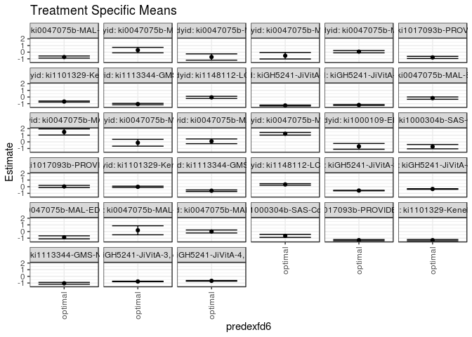

## Results Table

### Parameter: TSM

| agecat | studyid | country | intervention_level | baseline_level | estimate | ci_lower | ci_upper |
| --- | --- | --- | --- | --- | --- | --- | --- |
| Birth | ki0047075b-MAL-ED | BANGLADESH | optimal | observed | -0.8778364 | -1.1037553 | -0.6519176 |
| Birth | ki0047075b-MAL-ED | BRAZIL | optimal | observed | 0.1842677 | -0.4936490 | 0.8621844 |
| Birth | ki0047075b-MAL-ED | PERU | optimal | observed | 0.0046469 | -0.2186930 | 0.2279868 |
| Birth | ki1000304b-SAS-CompFeed | INDIA | optimal | observed | -0.6562835 | -0.8852815 | -0.4272855 |
| Birth | ki1017093b-PROVIDE | BANGLADESH | optimal | observed | -1.2991002 | -1.3874910 | -1.2107093 |
| Birth | ki1101329-Keneba | GAMBIA | optimal | observed | -1.3033587 | -1.4016781 | -1.2050392 |
| Birth | ki1113344-GMS-Nepal | NEPAL | optimal | observed | -1.0494536 | -1.1860678 | -0.9128394 |
| Birth | kiGH5241-JiVitA-3 | BANGLADESH | optimal | observed | -0.7687135 | -0.8056566 | -0.7317705 |
| Birth | kiGH5241-JiVitA-4 | BANGLADESH | optimal | observed | -0.6748650 | -0.7297550 | -0.6199750 |
| 6 months | ki0047075b-MAL-ED | BANGLADESH | optimal | observed | -0.1652675 | -0.3375635 | 0.0070286 |
| 6 months | ki0047075b-MAL-ED | BRAZIL | optimal | observed | 1.4868898 | 1.0278642 | 1.9459155 |
| 6 months | ki0047075b-MAL-ED | INDIA | optimal | observed | -0.1346697 | -0.6472605 | 0.3779212 |
| 6 months | ki0047075b-MAL-ED | NEPAL | optimal | observed | 0.0805405 | -0.2762151 | 0.4372962 |
| 6 months | ki0047075b-MAL-ED | PERU | optimal | observed | 1.2188016 | 1.0181539 | 1.4194493 |
| 6 months | ki1000109-EE | PAKISTAN | optimal | observed | -0.6771604 | -1.1086914 | -0.2456295 |
| 6 months | ki1000304b-SAS-CompFeed | INDIA | optimal | observed | -0.7249143 | -1.0477394 | -0.4020893 |
| 6 months | ki1017093b-PROVIDE | BANGLADESH | optimal | observed | 0.0323884 | -0.1307832 | 0.1955600 |
| 6 months | ki1101329-Keneba | GAMBIA | optimal | observed | -0.0223220 | -0.1204032 | 0.0757593 |
| 6 months | ki1113344-GMS-Nepal | NEPAL | optimal | observed | -0.6075305 | -0.7234272 | -0.4916338 |
| 6 months | ki1148112-LCNI-5 | MALAWI | optimal | observed | 0.3360406 | 0.2159253 | 0.4561558 |
| 6 months | kiGH5241-JiVitA-3 | BANGLADESH | optimal | observed | -0.5850768 | -0.6226955 | -0.5474580 |
| 6 months | kiGH5241-JiVitA-4 | BANGLADESH | optimal | observed | -0.3470911 | -0.3918149 | -0.3023673 |
| 24 months | ki0047075b-MAL-ED | BANGLADESH | optimal | observed | -0.7337115 | -0.8929813 | -0.5744417 |
| 24 months | ki0047075b-MAL-ED | BRAZIL | optimal | observed | 0.3141300 | -0.0881783 | 0.7164384 |
| 24 months | ki0047075b-MAL-ED | INDIA | optimal | observed | -0.7293238 | -1.2031978 | -0.2554497 |
| 24 months | ki0047075b-MAL-ED | NEPAL | optimal | observed | -0.5338748 | -1.0241507 | -0.0435988 |
| 24 months | ki0047075b-MAL-ED | PERU | optimal | observed | 0.0794949 | -0.0957878 | 0.2547777 |
| 24 months | ki1017093b-PROVIDE | BANGLADESH | optimal | observed | -0.7909868 | -0.9529463 | -0.6290274 |
| 24 months | ki1101329-Keneba | GAMBIA | optimal | observed | -0.6831037 | -0.7629357 | -0.6032718 |
| 24 months | ki1113344-GMS-Nepal | NEPAL | optimal | observed | -1.0650701 | -1.1737372 | -0.9564029 |
| 24 months | ki1148112-LCNI-5 | MALAWI | optimal | observed | -0.0537916 | -0.2154906 | 0.1079074 |
| 24 months | kiGH5241-JiVitA-3 | BANGLADESH | optimal | observed | -1.2770512 | -1.3402937 | -1.2138088 |
| 24 months | kiGH5241-JiVitA-4 | BANGLADESH | optimal | observed | -1.1993720 | -1.2664304 | -1.1323136 |

### Parameter: E(Y)

| agecat | studyid | country | intervention_level | baseline_level | estimate | ci_lower | ci_upper |
| --- | --- | --- | --- | --- | --- | --- | --- |
| Birth | ki0047075b-MAL-ED | BANGLADESH | observed | observed | -0.9755670 | -1.1287016 | -0.8224325 |
| Birth | ki0047075b-MAL-ED | BRAZIL | observed | observed | 0.4643860 | 0.1360519 | 0.7927200 |
| Birth | ki0047075b-MAL-ED | PERU | observed | observed | -0.0587981 | -0.1871869 | 0.0695908 |
| Birth | ki1000304b-SAS-CompFeed | INDIA | observed | observed | -0.6596308 | -0.9005716 | -0.4186900 |
| Birth | ki1017093b-PROVIDE | BANGLADESH | observed | observed | -1.2984586 | -1.3752758 | -1.2216415 |
| Birth | ki1101329-Keneba | GAMBIA | observed | observed | -1.2599925 | -1.3251703 | -1.1948146 |
| Birth | ki1113344-GMS-Nepal | NEPAL | observed | observed | -1.1064559 | -1.2034951 | -1.0094168 |
| Birth | kiGH5241-JiVitA-3 | BANGLADESH | observed | observed | -0.7807809 | -0.8030521 | -0.7585097 |
| Birth | kiGH5241-JiVitA-4 | BANGLADESH | observed | observed | -0.6904586 | -0.7435822 | -0.6373351 |
| 6 months | ki0047075b-MAL-ED | BANGLADESH | observed | observed | -0.1213203 | -0.2539388 | 0.0112981 |
| 6 months | ki0047075b-MAL-ED | BRAZIL | observed | observed | 0.9720774 | 0.8078144 | 1.1363403 |
| 6 months | ki0047075b-MAL-ED | INDIA | observed | observed | -0.7067317 | -0.8369134 | -0.5765499 |
| 6 months | ki0047075b-MAL-ED | NEPAL | observed | observed | 0.1091407 | -0.0265536 | 0.2448351 |
| 6 months | ki0047075b-MAL-ED | PERU | observed | observed | 1.0506150 | 0.9281868 | 1.1730433 |
| 6 months | ki1000109-EE | PAKISTAN | observed | observed | -0.6106944 | -0.9239621 | -0.2974268 |
| 6 months | ki1000304b-SAS-CompFeed | INDIA | observed | observed | -0.6348861 | -0.7630511 | -0.5067211 |
| 6 months | ki1017093b-PROVIDE | BANGLADESH | observed | observed | -0.1990907 | -0.2817968 | -0.1163845 |
| 6 months | ki1101329-Keneba | GAMBIA | observed | observed | -0.1997647 | -0.2531388 | -0.1463906 |
| 6 months | ki1113344-GMS-Nepal | NEPAL | observed | observed | -0.6009171 | -0.6886356 | -0.5131986 |
| 6 months | ki1148112-LCNI-5 | MALAWI | observed | observed | 0.3925000 | 0.2735307 | 0.5114693 |
| 6 months | kiGH5241-JiVitA-3 | BANGLADESH | observed | observed | -0.6001300 | -0.6240378 | -0.5762223 |
| 6 months | kiGH5241-JiVitA-4 | BANGLADESH | observed | observed | -0.3968456 | -0.4358721 | -0.3578192 |
| 24 months | ki0047075b-MAL-ED | BANGLADESH | observed | observed | -0.8169756 | -0.9388013 | -0.6951499 |
| 24 months | ki0047075b-MAL-ED | BRAZIL | observed | observed | 0.4626233 | 0.2567495 | 0.6684971 |
| 24 months | ki0047075b-MAL-ED | INDIA | observed | observed | -0.9442584 | -1.0642426 | -0.8242742 |
| 24 months | ki0047075b-MAL-ED | NEPAL | observed | observed | -0.3674429 | -0.4840752 | -0.2508107 |
| 24 months | ki0047075b-MAL-ED | PERU | observed | observed | 0.1111982 | -0.0118399 | 0.2342362 |
| 24 months | ki1017093b-PROVIDE | BANGLADESH | observed | observed | -0.8928670 | -0.9755153 | -0.8102187 |
| 24 months | ki1101329-Keneba | GAMBIA | observed | observed | -0.8032329 | -0.8532842 | -0.7531817 |
| 24 months | ki1113344-GMS-Nepal | NEPAL | observed | observed | -1.1423525 | -1.2336321 | -1.0510729 |
| 24 months | ki1148112-LCNI-5 | MALAWI | observed | observed | -0.0770652 | -0.2204213 | 0.0662909 |
| 24 months | kiGH5241-JiVitA-3 | BANGLADESH | observed | observed | -1.3103375 | -1.3408810 | -1.2797940 |
| 24 months | kiGH5241-JiVitA-4 | BANGLADESH | observed | observed | -1.2265320 | -1.2620508 | -1.1910132 |

### Parameter: PAR

| agecat | studyid | country | intervention_level | baseline_level | estimate | ci_lower | ci_upper |
| --- | --- | --- | --- | --- | --- | --- | --- |
| Birth | ki0047075b-MAL-ED | BANGLADESH | optimal | observed | -0.0977306 | -0.2707052 | 0.0752440 |
| Birth | ki0047075b-MAL-ED | BRAZIL | optimal | observed | 0.2801183 | -0.3026619 | 0.8628985 |
| Birth | ki0047075b-MAL-ED | PERU | optimal | observed | -0.0634450 | -0.2492225 | 0.1223325 |
| Birth | ki1000304b-SAS-CompFeed | INDIA | optimal | observed | -0.0033473 | -0.0446450 | 0.0379504 |
| Birth | ki1017093b-PROVIDE | BANGLADESH | optimal | observed | 0.0006415 | -0.0464989 | 0.0477820 |
| Birth | ki1101329-Keneba | GAMBIA | optimal | observed | 0.0433662 | -0.0306247 | 0.1173571 |
| Birth | ki1113344-GMS-Nepal | NEPAL | optimal | observed | -0.0570024 | -0.1567812 | 0.0427764 |
| Birth | kiGH5241-JiVitA-3 | BANGLADESH | optimal | observed | -0.0120674 | -0.0427113 | 0.0185766 |
| Birth | kiGH5241-JiVitA-4 | BANGLADESH | optimal | observed | -0.0155936 | -0.0428726 | 0.0116853 |
| 6 months | ki0047075b-MAL-ED | BANGLADESH | optimal | observed | 0.0439471 | -0.0654115 | 0.1533057 |
| 6 months | ki0047075b-MAL-ED | BRAZIL | optimal | observed | -0.5148125 | -0.9358237 | -0.0938013 |
| 6 months | ki0047075b-MAL-ED | INDIA | optimal | observed | -0.5720620 | -1.0791145 | -0.0650095 |
| 6 months | ki0047075b-MAL-ED | NEPAL | optimal | observed | 0.0286002 | -0.3183263 | 0.3755267 |
| 6 months | ki0047075b-MAL-ED | PERU | optimal | observed | -0.1681866 | -0.3340954 | -0.0022778 |
| 6 months | ki1000109-EE | PAKISTAN | optimal | observed | 0.0664660 | -0.4245803 | 0.5575123 |
| 6 months | ki1000304b-SAS-CompFeed | INDIA | optimal | observed | 0.0900283 | -0.2741145 | 0.4541710 |
| 6 months | ki1017093b-PROVIDE | BANGLADESH | optimal | observed | -0.2314791 | -0.3753540 | -0.0876041 |
| 6 months | ki1101329-Keneba | GAMBIA | optimal | observed | -0.1774427 | -0.2582456 | -0.0966398 |
| 6 months | ki1113344-GMS-Nepal | NEPAL | optimal | observed | 0.0066134 | -0.0689233 | 0.0821500 |
| 6 months | ki1148112-LCNI-5 | MALAWI | optimal | observed | 0.0564594 | -0.0238227 | 0.1367416 |
| 6 months | kiGH5241-JiVitA-3 | BANGLADESH | optimal | observed | -0.0150533 | -0.0457142 | 0.0156077 |
| 6 months | kiGH5241-JiVitA-4 | BANGLADESH | optimal | observed | -0.0497545 | -0.0719515 | -0.0275575 |
| 24 months | ki0047075b-MAL-ED | BANGLADESH | optimal | observed | -0.0832641 | -0.1715611 | 0.0050329 |
| 24 months | ki0047075b-MAL-ED | BRAZIL | optimal | observed | 0.1484933 | -0.2028332 | 0.4998197 |
| 24 months | ki0047075b-MAL-ED | INDIA | optimal | observed | -0.2149346 | -0.6828729 | 0.2530036 |
| 24 months | ki0047075b-MAL-ED | NEPAL | optimal | observed | 0.1664318 | -0.3083576 | 0.6412213 |
| 24 months | ki0047075b-MAL-ED | PERU | optimal | observed | 0.0317032 | -0.0989779 | 0.1623844 |
| 24 months | ki1017093b-PROVIDE | BANGLADESH | optimal | observed | -0.1018802 | -0.2433769 | 0.0396165 |
| 24 months | ki1101329-Keneba | GAMBIA | optimal | observed | -0.1201292 | -0.1842959 | -0.0559625 |
| 24 months | ki1113344-GMS-Nepal | NEPAL | optimal | observed | -0.0772825 | -0.1507723 | -0.0037926 |
| 24 months | ki1148112-LCNI-5 | MALAWI | optimal | observed | -0.0232736 | -0.0895832 | 0.0430359 |
| 24 months | kiGH5241-JiVitA-3 | BANGLADESH | optimal | observed | -0.0332862 | -0.0889534 | 0.0223809 |
| 24 months | kiGH5241-JiVitA-4 | BANGLADESH | optimal | observed | -0.0271600 | -0.0782502 | 0.0239301 |